# D. Explore

Jeffrey W. Hollister & Emily Read

19 June, 2015

Our next three lessons (Explore, Analyze, and Visualize) don’t actually split neatly into groups. That being said, I will try my best, but there will be overlap. For this lesson we are going to focus on some of the first things you do when you start to explore a dataset including basic summary statistics and simple visualizations with base R.

## Quick Links to Exercises and R code

- Lesson 4 R Code: All the code from this post in an R Script.
- Exercise 1: Exploring data with basic summary statistics
- Exercise 2: Using base R graphics for exploratory data analysis

## Lesson Goals

- Be able to calculate a variety of summary statistics
- Continue building familiarity with `dplyr` and base R for summarizing groups
- Create a variety of simple exploratory plots

## Summary Statistics

There are a number of ways to get at the basic summaries of a data frame in R. The easiest is to use `summary()` which for data frames will return a summary of each column. For numeric columns it gives quantiles, median, etc. and for factor a frequency of the terms. Let’s go back to iris and take a look.

```r
summary(iris)
```

```
##   Sepal.Length    Sepal.Width     Petal.Length    Petal.Width
##  Min.   :4.300   Min.   :2.000   Min.   :1.000   Min.   :0.100
##  1st Qu.:5.100   1st Qu.:2.800   1st Qu.:1.600   1st Qu.:0.300
##  Median :5.800   Median :3.000   Median :4.350   Median :1.300
##  Mean   :5.843   Mean   :3.057   Mean   :3.758   Mean   :1.199
##  3rd Qu.:6.400   3rd Qu.:3.300   3rd Qu.:5.100   3rd Qu.:1.800
##  Max.   :7.900   Max.   :4.400   Max.   :6.900   Max.   :2.500
##        Species
##  setosa    :50
##  versicolor:50
##  virginica :50
##
##
##
```

If you want to look at the range, use `range()`, but it is looking for a vector as input.

```r
range(iris$Petal.Length)
```

```
## [1] 1.0 6.9
```

The interquatile range can be easily grabbed with `IQR()`, again a vector is the input.

```r
IQR(iris$Sepal.Width)
```

```
## [1] 0.5
```

Lastly, quantiles, at specific points, can be returned with, well, `quantile()`.

```r
quantile(iris$Sepal.Length)
```

```
##   0%  25%  50%  75% 100%
##  4.3  5.1  5.8  6.4  7.9
```

I use quantile quite a bit, as it provides a bit more flexibility because you can specify the probabilities you want to return.

```r
quantile(iris$Sepal.Length, probs=(c(0.025,0.975)))
```

```
##   2.5%  97.5%
## 4.4725 7.7000
```

## Exercise 1

Next, we’re going to explore the distribution of the NM phosphorus data using base R statistical functions

1. For this first part, explore each of the functions above (`summary()`, `range()`, `IQR()`, and `quantile()`) and get to know more about the NWIS water variables we collected and merged into our ‘gages_data_wq’ data frame. Specifically, you’ll want to focus on the ‘results_xx’ variables within the ‘gages_data_wq’ data frame Hint: Use the $ operator to index a particular columns of this data frame using the functions above.

OPTIONAL: Next lets continue to add to our script. This time we will be combining some of the past lessons with this one. Our goal is to create a summary statistics data frame of `gages_data_wq`. What we want is a data frame that has min, max, mean, median, IQR, and quartiles for each of the four varaibles measured at ‘gages’ sites in NM that we pulled from NWIS. This may seem a bit daunting, but if we break it apart it gets a bit easier. This is a base R solution.

2. Create a separate vector for each of the water quality variables. The vector should be of length 7. You can choose the name of the vector; choose something descriptive that would be obvious to your neighbor if you shared the script or data frame.
3. Make sure your column names AND row names make sense.

## Basic Visualization

Exploratory data analysis tends to be a little bit about stats and a lot about visualization. Later we are going to go into more detail on `ggplot2` which is becoming the gold standard of viz in R, but for now we will look at some of the simple, yet very useful, plots that come with base R. I find these to be great ways to quickly explore data.

The workhorse function for plotting data in R is `plot()`. With this one command you can create almost any plot you can conceive of, but for this workshop we are just going to look at the very basics of the function. The most common way to use `plot()` is for scatterplots. Let’s look at the `mtcars` data.

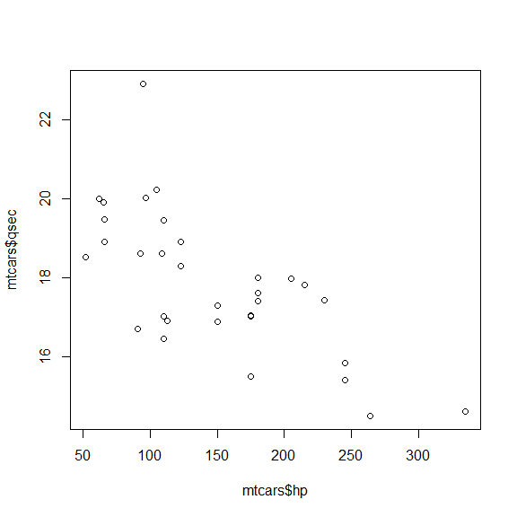

```r
plot(mtcars$hp,mtcars$qsec)
```

Hey, a plot! Not bad. Let’s customize a bit because those axis labels aren’t terribly useful and we need a title. For that we can use the `main`, `xlab`, and `ylab` arguments.

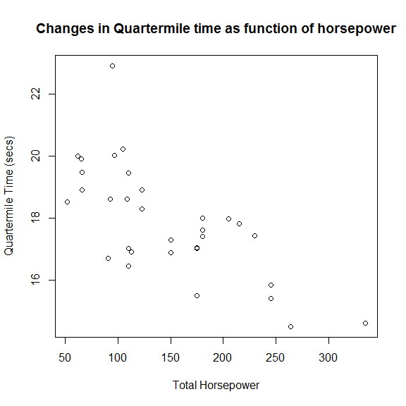

```r
plot(mtcars$hp,mtcars$qsec,main="Changes in Quartermile time as function of horsepower",
     xlab="Total Horsepower",ylab="Quartermile Time (secs)")
```

Not sure if this will apply to everyone, but I use scatterplots ALL the time. So, for me I could almost (not really) stop here. But lets move on. Let’s say we want to look at more than just one relationship at a time with a pairs plot. Again, `plot()` is our friend. If you pass a data frame to `plot()` instead of an x and y vector it will plot all possible pairs. Be careful though, as too many columns will produce an unintelligble plot. Let’s go back to `iris`.

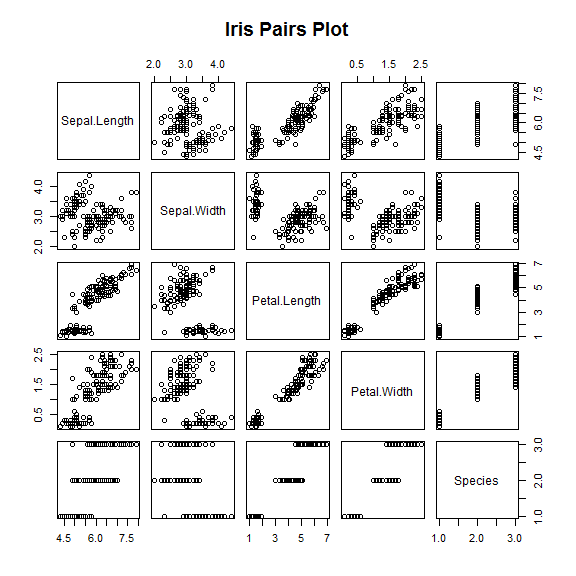

```r
plot(iris, main="Iris Pairs Plot")
```

Last thing I will show with plot is how to add a line. The one I use most often for exploratory analysis is a straight line defined by slope and intercept. We do this with `abline()`.

We can add a horizontal line and vertical line easily with this as follows:

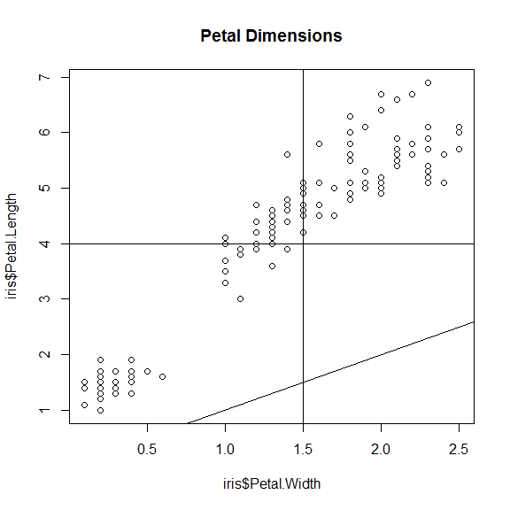

```r
plot(iris$Petal.Width,iris$Petal.Length, main="Petal Dimensions")
#horizontal line at specified y value
abline(h=4)
#a vertical line
abline(v=1.5)
#Line with a slope and intercept
abline(0,1)
```

This is useful if you have a known value that you want to compare to your data. Next example is putting a regression line on the plot. We haven’t talked about regression in R yet, but this example is simple enough I think we can get away with introducing it.

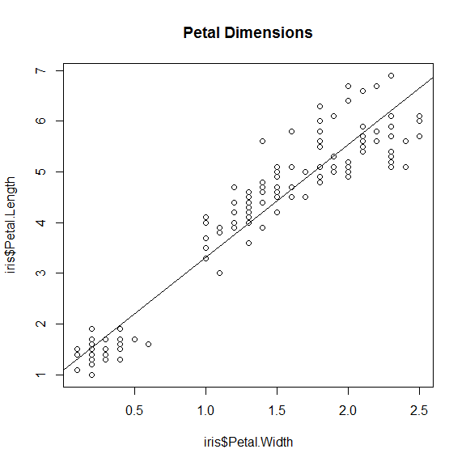

```r
plot(iris$Petal.Width,iris$Petal.Length, main="Petal Dimensions")
#abline accepts a liner model object as input
#linear model is done with lm, and uses a formula as input
abline(lm(Petal.Length~Petal.Width,data=iris))
```

So, we detoured a bit. Let’s get back to a few more examples of exploratory plots. We will look at boxplots, histograms, and cumulative distribution functions then call it quits on the exploratory analyis (and the first day, whew!)

Two great ways to use boxplots are straight up and then by groups in a factor. For this we will use `boxplot()` and in this case it is looking for a vector as input. Sticking with `iris`:

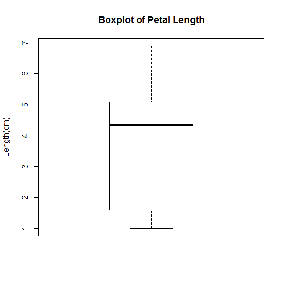

```r
boxplot(iris$Petal.Length, main="Boxplot of Petal Length",ylab="Length(cm)")
```

As plots go, well, um, not great. Let’s try it with a bit more info and create a boxplot for each of the groups.

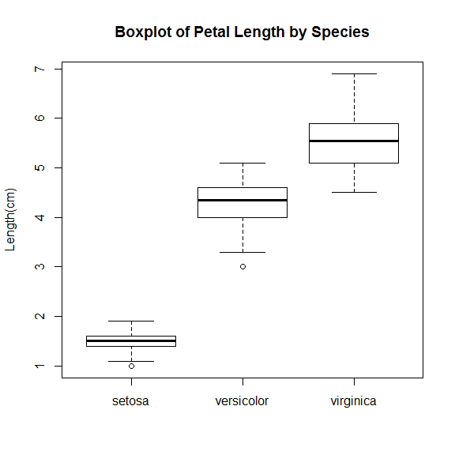

```r
boxplot(iris$Petal.Length~iris$Species, main="Boxplot of Petal Length by Species",ylab="Length(cm)")
```

Lastly, let’s look at two other ways to plot our distributions. First, histograms.

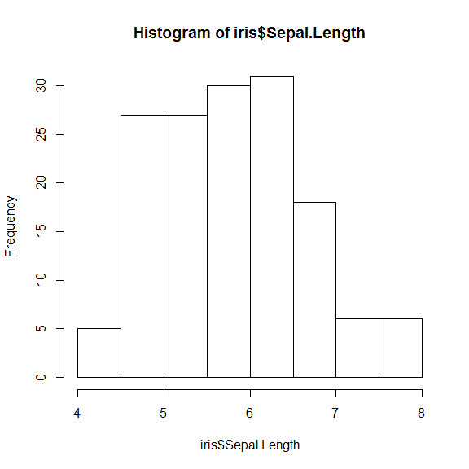

```r
hist(iris$Sepal.Length)
```

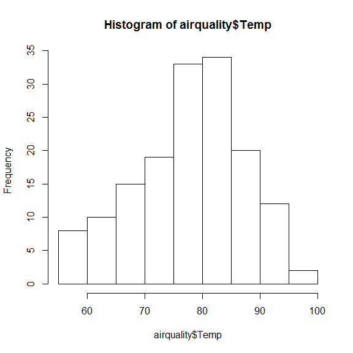

```r
hist(airquality$Temp,breaks=10)
```

And finally, cumulative distribution functions. Since CDF’s are actually a function of the distribution we need to get that function first. This requires that we combine `plot()` and `ecdf()`, the emprical CDF function.

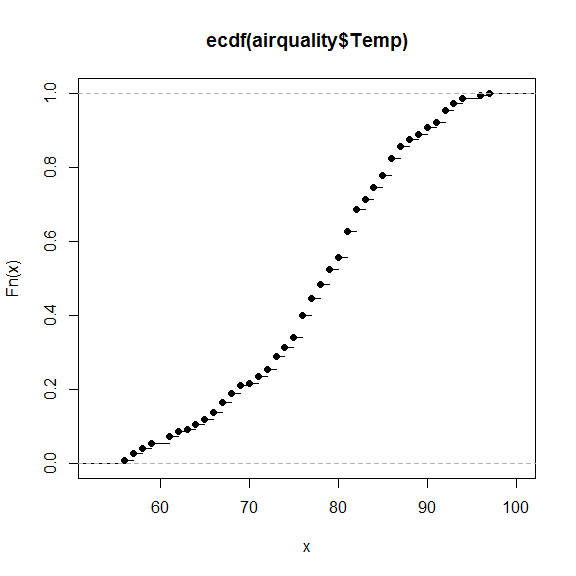

```r
aq_temp_ecdf<-ecdf(airquality$Temp)
plot(aq_temp_ecdf)
```

## Exercise 2

Similar to before let’s first just play around with some basic exploratory data visualization using water quality data in your newly created ‘gages_data_wq’ data frame.

1. Try out each of the plotting commands discussed above and explore any of the data in our `gages_data_wq` data frame.
2. Let’s add another section to the script to create a pairs plot of the NM data physical and water quality we have collected so far (phosphorus, discharge, temperature, and specific conductance).
3. Lastly, add a boxplot of discharge that shows a boxplot for [NSIP Sentinel](http://water.usgs.gov/nsip/federalneeds.html) (‘NSIP_SENTINEL’) sites versus non-Sentinel sites. Feel free to try and log transform the discharge data (not required).